# Bladder cancer survival: women only fare worse in the first two years after diagnosis

Author: Anke Richters

Date: August 2019

Analyses used the folllowing libraries:

- `markdown`
- `rstpm2`
- `readr`
- `knitr`
- `kableExtra`
- `survminer`
- `ggplot2`

## DATA

**NKR data and CBS lifetables**

Data was used from the Netherlands Cancer Registry (NCR) of all patients:

- with bladder cancer;
- T1 or higher (all bladder cancers except Ta or Tis);
- histologically confirmed;
- diagnosed in 2003-2012.

Data on mortality rates of the Dutch general population were obtained from CBS (Centraal Bureau voor Statistiek).  
Data sources are merged together.  
Lifetables were not available for age>99 and year>2017.  
Patients who survived past 10 years are censored at 10 years.

The merged data look like this (n=24,169):

- Vitstat (1=deceased, 0=censored)
- Fupyrs (time to vitstat in years)
- Sex (0=male, 1=female)
- Age = age in years at diagnosis
- Tstage (numerical)
- Nstage (dichotomous, N0 / N+)
- Mstage (dichotomous, M0 / M+)
- Morf = histology (0=urothelial carcinoma, 1=non-urothelial carcinoma)
- Rate = background hazard from life-tables
- Rate_sxx = background hazard from life-tables adapted based on several sensitivity scenarios

## MODELLING

#### Model summaries

Basic model (sex + covariates + interaction terms between sex and covariates):

```
## Maximum likelihood estimation
##
## Call:
## stpm2(formula = Surv(fupyrs, vitstat) ~ sex + nsx(age, df = 3,
##     centre = 72) + tstage + nstage + mstage + morf + sex:nsx(age,
##     df = 3, centre = 72) + sex:tstage + sex:nstage + sex:mstage +
##     sex:morf, data = dataset, df = 1, bhazard = dataset$rate)
##
## Coefficients:
##                                      Estimate Std. Error   z value
## (Intercept)                        -7.6003709  0.0566958 -134.0553
## sex                                 0.0192267  0.0568183    0.3384
## nsx(age, df = 3, centre = 72)1      0.9424409  0.0903078   10.4359
## nsx(age, df = 3, centre = 72)2      1.2346008  0.4251359    2.9040
## nsx(age, df = 3, centre = 72)3      2.0487423  0.1971151   10.3936
## tstage                              0.5801102  0.0128631   45.0987
## nstage                              0.4976366  0.0364430   13.6552
## mstage                              1.1577249  0.0392658   29.4843
## morf                                0.2625751  0.0492784    5.3284
## nsx(log(fupyrs), df = 1)            8.0326962  0.0637039  126.0942
## sex:nsx(age, df = 3, centre = 72)1  0.0744740  0.1387697    0.5367
## sex:nsx(age, df = 3, centre = 72)2 -0.6123343  0.6336255   -0.9664
## sex:nsx(age, df = 3, centre = 72)3 -0.0406079  0.2863236   -0.1418
## sex:tstage                          0.0691244  0.0233456    2.9609
## sex:nstage                          0.0244829  0.0645350    0.3794
## sex:mstage                         -0.2435834  0.0701446   -3.4726
## sex:morf                           -0.0036861  0.0749272   -0.0492
##                                        Pr(z)
## (Intercept)                        < 2.2e-16 ***
## sex                                0.7350696
## nsx(age, df = 3, centre = 72)1     < 2.2e-16 ***
## nsx(age, df = 3, centre = 72)2     0.0036841 **
## nsx(age, df = 3, centre = 72)3     < 2.2e-16 ***
## tstage                             < 2.2e-16 ***
## nstage                             < 2.2e-16 ***
## mstage                             < 2.2e-16 ***
## morf                               9.908e-08 ***
## nsx(log(fupyrs), df = 1)           < 2.2e-16 ***
## sex:nsx(age, df = 3, centre = 72)1 0.5914934
## sex:nsx(age, df = 3, centre = 72)2 0.3338452
## sex:nsx(age, df = 3, centre = 72)3 0.8872180
## sex:tstage                         0.0030672 **
## sex:nstage                         0.7044107
## sex:mstage                         0.0005155 ***
## sex:morf                           0.9607635
## ---
## Signif. codes:  0 '***' 0.001 '**' 0.01 '*' 0.05 '.' 0.1 ' ' 1
##
## -2 log L: 70627.69
```

Basic model + spline for baseline hazard with 4 df:

```
## Maximum likelihood estimation
##
## Call:
## stpm2(formula = Surv(fupyrs, vitstat) ~ sex + nsx(age, df = 3,
##     centre = 72) + tstage + nstage + mstage + morf + sex:nsx(age,
##     df = 3, centre = 72) + sex:tstage + sex:nstage + sex:mstage +
##     sex:morf, data = dataset, df = 4, bhazard = dataset$rate,
##     link.type = "PH")
##
## Coefficients:
##                                      Estimate Std. Error  z value
## (Intercept)                        -10.679607   0.222864 -47.9198
## sex                                  0.046430   0.058109   0.7990
## nsx(age, df = 3, centre = 72)1       0.761031   0.091195   8.3451
## nsx(age, df = 3, centre = 72)2       0.930295   0.426816   2.1796
## nsx(age, df = 3, centre = 72)3       1.856343   0.194589   9.5398
## tstage                               0.576350   0.012929  44.5795
## nstage                               0.465760   0.036122  12.8942
## mstage                               1.138672   0.038835  29.3208
## morf                                 0.313093   0.049027   6.3861
## nsx(log(fupyrs), df = 4)1            8.311674   0.218339  38.0677
## nsx(log(fupyrs), df = 4)2            7.122338   0.147558  48.2679
## nsx(log(fupyrs), df = 4)3           14.236212   0.435213  32.7109
## nsx(log(fupyrs), df = 4)4            5.963867   0.087641  68.0492
## sex:nsx(age, df = 3, centre = 72)1   0.136387   0.139451   0.9780
## sex:nsx(age, df = 3, centre = 72)2  -0.429026   0.634871  -0.6758
## sex:nsx(age, df = 3, centre = 72)3  -0.015003   0.282286  -0.0531
## sex:tstage                           0.068661   0.023459   2.9268
## sex:nstage                           0.035283   0.063969   0.5516
## sex:mstage                          -0.244785   0.069525  -3.5208
## sex:morf                            -0.042102   0.074777  -0.5630
##                                        Pr(z)
## (Intercept)                        < 2.2e-16 ***
## sex                                0.4242806
## nsx(age, df = 3, centre = 72)1     < 2.2e-16 ***
## nsx(age, df = 3, centre = 72)2     0.0292859 *
## nsx(age, df = 3, centre = 72)3     < 2.2e-16 ***
## tstage                             < 2.2e-16 ***
## nstage                             < 2.2e-16 ***
## mstage                             < 2.2e-16 ***
## morf                               1.701e-10 ***
## nsx(log(fupyrs), df = 4)1          < 2.2e-16 ***
## nsx(log(fupyrs), df = 4)2          < 2.2e-16 ***
## nsx(log(fupyrs), df = 4)3          < 2.2e-16 ***
## nsx(log(fupyrs), df = 4)4          < 2.2e-16 ***
## sex:nsx(age, df = 3, centre = 72)1 0.3280613
## sex:nsx(age, df = 3, centre = 72)2 0.4991881
## sex:nsx(age, df = 3, centre = 72)3 0.9576145
## sex:tstage                         0.0034242 **
## sex:nstage                         0.5812430
## sex:mstage                         0.0004302 ***
## sex:morf                           0.5734141
## ---
## Signif. codes:  0 '***' 0.001 '**' 0.01 '*' 0.05 '.' 0.1 ' ' 1
##
## -2 log L: 68760.15
```

Basic model with baseline hazard spline with time-covariate interactions to allow for non-proportional hazards over time (final model):

```
## Maximum likelihood estimation
##
## Call:
## stpm2(formula = Surv(fupyrs, vitstat) ~ sex + nsx(age, df = 3,
##     centre = 72) + tstage + nstage + mstage + morf + sex:nsx(age,
##     df = 3, centre = 72) + sex:tstage + sex:nstage + sex:mstage +
##     sex:morf, data = dataset, df = 4, tvc = list(sex = 1, age = 4,
##     tstage = 2), bhazard = dataset$rate, link.type = "PH")
##
## Coefficients:
##                                       Estimate  Std. Error  z value
## (Intercept)                        -10.6521885   0.4501575 -23.6632
## sex                                  0.8292614   0.1221060   6.7913
## nsx(age, df = 3, centre = 72)1       1.6522016   0.9981340   1.6553
## nsx(age, df = 3, centre = 72)2       2.6886489   2.1652358   1.2417
## nsx(age, df = 3, centre = 72)3       2.8014320   1.2812300   2.1865
## tstage                               0.4419822   0.1337389   3.3048
## nstage                               0.4713639   0.0362439  13.0053
## mstage                               1.1347431   0.0391984  28.9487
## morf                                 0.3194052   0.0489369   6.5269
## nsx(log(fupyrs), df = 4)1            9.2030543   1.6031923   5.7405
## nsx(log(fupyrs), df = 4)2            8.9656087   1.0879080   8.2411
## nsx(log(fupyrs), df = 4)3           14.6622573   3.1603218   4.6395
## nsx(log(fupyrs), df = 4)4            8.2254024   0.6516339  12.6227
## sex:nsx(age, df = 3, centre = 72)1  -0.0233524   0.1401478  -0.1666
## sex:nsx(age, df = 3, centre = 72)2  -0.5512208   0.6359022  -0.8668
## sex:nsx(age, df = 3, centre = 72)3  -0.2021578   0.2874275  -0.7033
## sex:tstage                           0.0330482   0.0237531   1.3913
## sex:nstage                          -0.0040787   0.0639934  -0.0637
## sex:mstage                          -0.2831257   0.0698970  -4.0506
## sex:morf                            -0.0516254   0.0747796  -0.6904
## sex:nsx(log(fupyrs), df = 1)        -1.0224862   0.1429864  -7.1509
## nsx(log(fupyrs), df = 4)1:age       -0.0151342   0.0202365  -0.7479
## nsx(log(fupyrs), df = 4)2:age       -0.0233430   0.0136368  -1.7118
## nsx(log(fupyrs), df = 4)3:age       -0.0115758   0.0403337  -0.2870
## nsx(log(fupyrs), df = 4)4:age       -0.0233098   0.0080896  -2.8815
## tstage:nsx(log(fupyrs), df = 2)1     0.3710335   0.2422379   1.5317
## tstage:nsx(log(fupyrs), df = 2)2    -0.2044914   0.0490032  -4.1730
##                                        Pr(z)
## (Intercept)                        < 2.2e-16 ***
```

[output cut: 15 more lines]

```
## sex:tstage                         0.1641265
## sex:nstage                         0.9491806
## sex:mstage                         5.108e-05 ***
## sex:morf                           0.4899628
## sex:nsx(log(fupyrs), df = 1)       8.619e-13 ***
## nsx(log(fupyrs), df = 4)1:age      0.4545426
## nsx(log(fupyrs), df = 4)2:age      0.0869399 .
## nsx(log(fupyrs), df = 4)3:age      0.7741118
## nsx(log(fupyrs), df = 4)4:age      0.0039582 **
## tstage:nsx(log(fupyrs), df = 2)1   0.1255989
## tstage:nsx(log(fupyrs), df = 2)2   3.006e-05 ***
## ---
## Signif. codes:  0 '***' 0.001 '**' 0.01 '*' 0.05 '.' 0.1 ' ' 1
##
## -2 log L: 68464.63
```

## RESULTS

**Models and figures used in paper**

All the standardized survival functions are corrected for age at diagnosis, T-stage, N-stage, M-stage and histology.

### Table 1

Baseline characteristics of a population-  
based cohort of 24,169 bladder cancer patients

|  | 0 (n=18345) | 1 (n=5824) | Overall (n=24169) |
| --- | --- | --- | --- |
| age |  |  |  |
| Mean (SD) | 71.3 (10.5) | 71.2 (12.3) | 71.2 (11.0) |
| Median [Min, Max] | 72.0 [22.0, 101] | 73.0 [22.0, 102] | 72.0 [22.0, 102] |
| factor(tstage) |  |  |  |
| 1 | 8809 (48.0%) | 2091 (35.9%) | 10900 (45.1%) |
| 2 | 7014 (38.2%) | 2390 (41.0%) | 9404 (38.9%) |
| 3 | 1306 (7.1%) | 664 (11.4%) | 1970 (8.2%) |
| 4 | 1216 (6.6%) | 679 (11.7%) | 1895 (7.8%) |
| factor(nstage) |  |  |  |
| 0 | 16649 (90.8%) | 5092 (87.4%) | 21741 (90.0%) |
| 1 | 1696 (9.2%) | 732 (12.6%) | 2428 (10.0%) |
| factor(mstage) |  |  |  |
| 0 | 17179 (93.6%) | 5329 (91.5%) | 22508 (93.1%) |
| 1 | 1166 (6.4%) | 495 (8.5%) | 1661 (6.9%) |
| factor(morf) |  |  |  |
| 0 | 17576 (95.8%) | 5276 (90.6%) | 22852 (94.6%) |
| 1 | 769 (4.2%) | 548 (9.4%) | 1317 (5.4%) |

*Models:*

```r
basic  <- stpm2(Surv(fupyrs, vitstat)~sex,
              data=dataset, df=4,
              bhazard=dataset$rate,
              tvc=list(sex=1))

basic_rel<- stpm2(Surv(fupyrs, vitstat)~sex+nsx(age, df=3, centre=72),
              data=dataset, df=4,
              bhazard=dataset$rate,
              tvc=list(sex=1,age=4), link.type="PH")

full <- stpm2(Surv(fupyrs, vitstat)~sex+nsx(age, df=3, centre=72)+tstage+nstage+mstage+morf+
              sex:nsx(age, df=3, centre=72)+sex:tstage+sex:nstage+sex:mstage+sex:morf, df=4,
              tvc=list(sex=1, age=4, tstage=2),
              data=dataset,
              bhazard=dataset$rate, link.type="PH")
```

### Figure 1

**Modelled overall and relative survival of male and female bladder cancer patients**

```r
#Observed and relative survival model:
obs<- stpm2(Surv(fupyrs, vitstat)~sex, data=dataset, df=4,tvc=list(sex=1))
rel<- stpm2(Surv(fupyrs, vitstat)~sex+nsx(age, df=3, centre=72), data=dataset, df=4, bhazard=dataset$rate, tvc=list(sex=1,age=4))
```

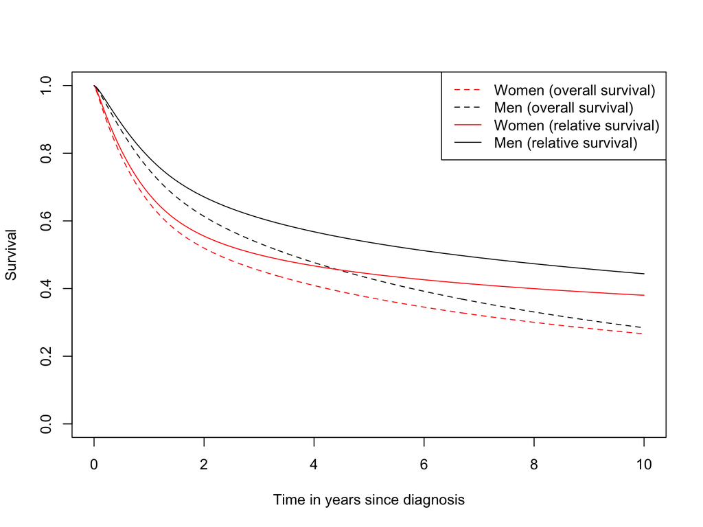

```r
plot(obs,newdata=data.frame(sex=1),type="surv",var="sex",add=F,ci=F,line.col=2, lty=2,
     xlim=c(0,10), ylim=c(0,1), xlab="Time in years since diagnosis", ylab="Survival",rug=FALSE)
plot(obs,newdata=data.frame(sex=0),type="surv",var="sex",add=T,ci=F,line.col=1, lty=2,rug=FALSE)
plot(rel,newdata=transform(dataset, sex=1), type="meansurv",var="sex",add=T,ci=F,line.col=2, lty=1,rug=FALSE)
plot(rel,newdata=transform(dataset, sex=0),type="meansurv",var="sex",add=T,ci=F,line.col=1, lty=1,rug=FALSE)
legend("topright",c("Women (overall survival)","Men (overall survival)",
                    "Women (relative survival)","Men (relative survival)"),
       col=c(2,1,2,1), lty=c(2,2,1,1))
```

### Figure 2A

**Unadjusted and adjusted relative survival by sex in bladder cancer patients**

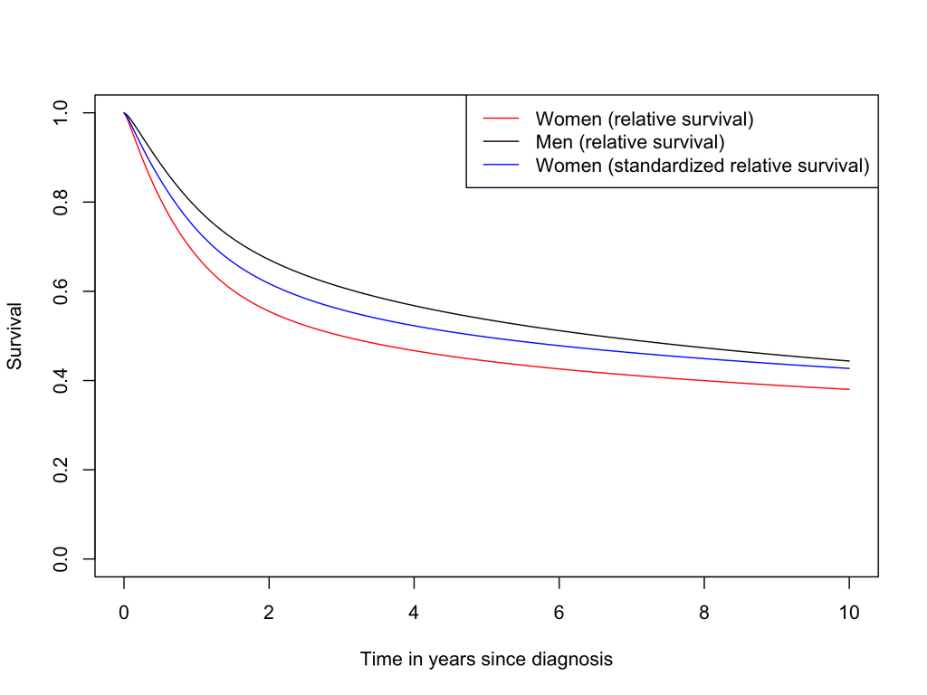

```r
#Plot relative survival of men and women, only standardized for age
# Women
plot(basic_rel,newdata=transform(dataset, sex=1),type="meansurv",var="sex",add=F,ci=F,line.col=2, lty=1,
ylim=c(0,1), xlim=c(0,10), xlab="Time in years since diagnosis", ylab="Survival",rug=FALSE)
# Men
plot(basic_rel,newdata=transform(dataset, sex=0),type="meansurv",var="sex",add=T,ci=F,line.col=1, lty=1,rug=FALSE)

# Plot relative survival of women with men's covariate distribution
subset_men<-subset(dataset, sex==0)      # select only men
subset_men$sex<-1                        # set men's covariate distribution to females
plot(full,newdata=transform(subset_men, sex=1), type="meansurv", add=T, line.col=4, lty=1,rug=FALSE)

legend("topright",c("Women (relative survival)","Men (relative survival)",
                    "Women (standardized relative survival)"),
       col=c(2,1,4), lty=c(1,1,1))
```

### Figure 2B

**Unadjusted and adjusted excess hazard by sex in bladder cancer patients**

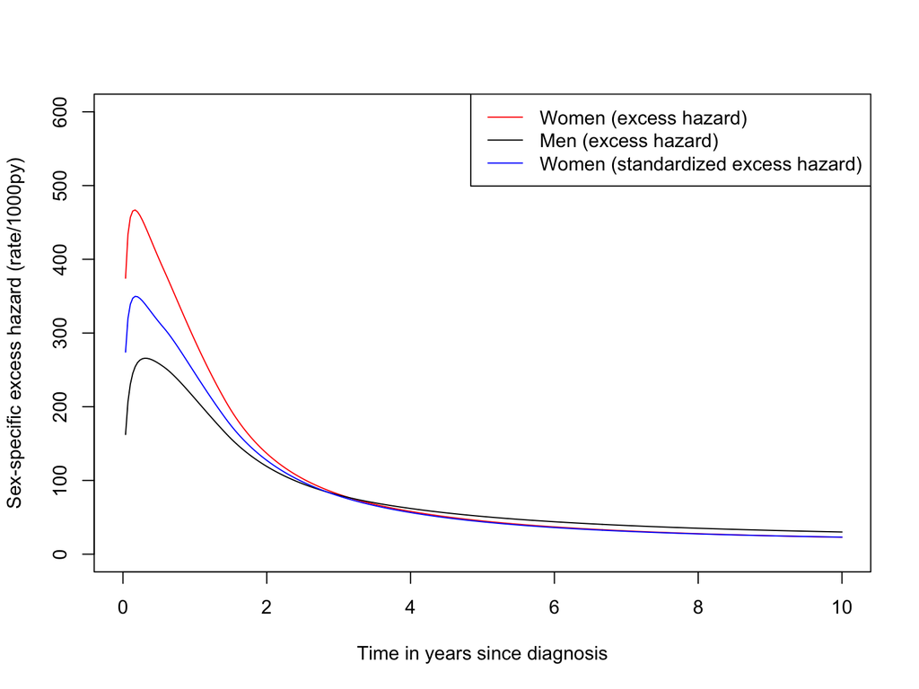

```r
yticks <- c(0,0.1,0.2,0.3,0.4,0.5,0.6)
ylabels <- c(0,100,200,300,400,500,600)

#Plot hazard functions of men and women, only standardized for age

#Women
plot(basic_rel,newdata=transform(dataset, sex=1),type="meanhaz", var="sex",add=F, ci=F, line.col=2,lty=1,
     ylim=c(0,0.6), xlim=c(0,10), xlab="Time in years since diagnosis", ylab="Sex-specific excess hazard (rate/1000py)", yaxt="n",rug=FALSE)
#Men
plot(basic_rel,newdata=transform(dataset, sex=0),type="meanhaz", var="sex",add=T, ci=F, line.col=1,lty=1,rug=FALSE)
axis(2, at=yticks, labels=ylabels)

# Plot relative survival of women with men's covariate distribution
subset_men<-subset(dataset, sex==0)      # select only men
subset_men$sex<-1                        # change 'man' to 'woman' so now it's a group of women with men's covariates
plot(full,newdata=transform(subset_men, sex=1), type="meanhaz", add=T, line.col=4, lty=1,rug=FALSE)

legend("topright",c("Women (excess hazard)","Men (excess hazard)",
                    "Women (standardized excess hazard)"),
       col=c(2,1,4), lty=c(1,1,1))
```

### Figure 3A

**Unadjusted and adjusted excess hazard ratio for sex**

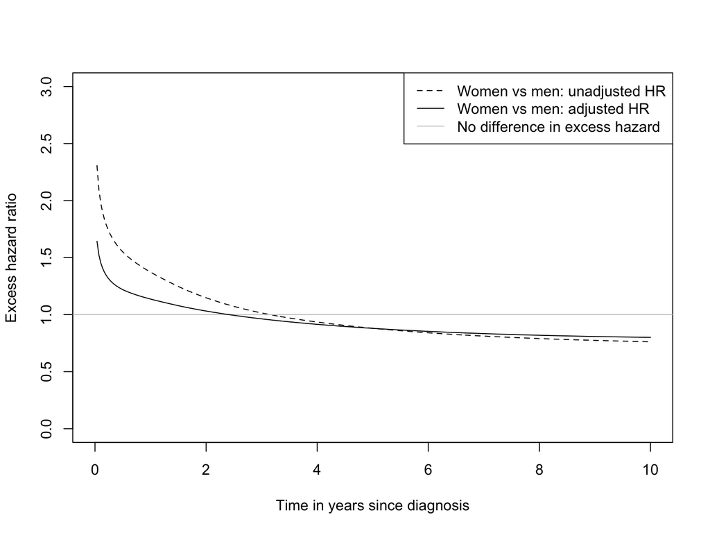

```r
#Plot hazard ratio curve in dashed line
plot(basic_rel,newdata=transform(dataset, sex=0),type="meanhr", var="sex",add=F, ci=F, line.col=1,lty=2,
     ylim=c(0,3), xlim=c(0,10), xlab="Time in years since diagnosis", ylab="Excess hazard ratio",rug=FALSE)
abline(h=1, col="grey80",lty=1)

#Plot standardized hazard ratio curve in normal line
plot(full,newdata=transform(dataset, sex=0), type="meanhr", var="sex", add=T, line.col=1, lty=1,rug=FALSE)
legend("topright",c("Women vs men: unadjusted HR","Women vs men: adjusted HR","No difference in excess hazard"),
       col=c(1,1,"grey80"), lty=c(2,1,1))
```

### Figure 3B

**Adjusted excess hazard ratios for age, T-stage, N-stage, M-stage and histology in bladder cancer patients**

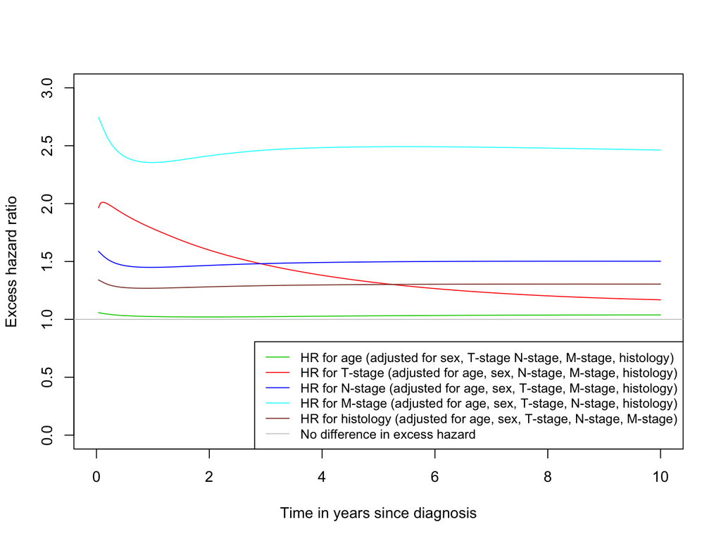

```r
full <- stpm2(Surv(fupyrs, vitstat)~sex+nsx(age, df=3, centre=72)+tstage+nstage+mstage+morf+
                                 sex:nsx(age, df=3, centre=72)+sex:tstage+sex:nstage+sex:mstage+sex:morf, df=4,
                                 tvc=list(sex=1, age=4, tstage=2),
                                 data=dataset, bhazard=dataset$rate, link.type="PH")

#Plot standardized hazard ratio curve of each factor
plot(full,newdata=transform(dataset, tstage=1), type="meanhr", var="tstage", add=F, line.col=2, lty=1,
           ylim=c(0,3), xlim=c(0,10), xlab="Time in years since diagnosis", ylab="Excess hazard ratio",rug=FALSE)
plot(full,newdata=transform(dataset, age=72), type="meanhr", var="age", add=T, line.col=3, lty=1,rug=FALSE)
plot(full,newdata=transform(dataset, nstage=0), type="meanhr", var="nstage", add=T, line.col=4, lty=1,rug=FALSE)
plot(full,newdata=transform(dataset, mstage=0), type="meanhr", var="mstage", add=T, line.col=5, lty=1,rug=FALSE)
plot(full,newdata=transform(dataset, morf=0), type="meanhr", var="morf", add=T, line.col="coral4", lty=1,rug=FALSE)

legend("bottomright",c("HR for age (adjusted for sex, T-stage N-stage, M-stage, histology)",
                    "HR for T-stage (adjusted for age, sex, N-stage, M-stage, histology)",
                    "HR for N-stage (adjusted for age, sex, T-stage, M-stage, histology)",
                    "HR for M-stage (adjusted for age, sex, T-stage, N-stage, histology)",
                    "HR for histology (adjusted for age, sex, T-stage, N-stage, M-stage)",
                    "No difference in excess hazard"),
       col=c(3,2,4,5,"coral4","grey80"), lty=c(1,1,1,1,1,1),
       cex=0.85)
abline(h=1, col="grey80",lty=1)
```

### Figure 4A

**Adjusted excess hazard ratios for sex in patients with NMIBC and MIBC**

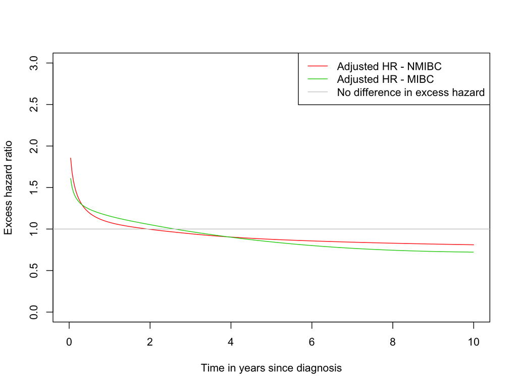

```r
# T-stage subgroups: NMIBC vs MIBC
tstage1 <- subset(dataset, tstage==1)
tstage2 <- subset(dataset, tstage>1)

#All factors associated with T-stage are removed in the first model because every patient has T-stage 1 there.
fullt1<- stpm2(Surv(fupyrs, vitstat)~sex+nsx(age, df=3, centre=72)+nstage+mstage+morf+
                 sex:nsx(age, df=3, centre=72)+sex:nstage+sex:mstage+sex:morf, df=4,
               tvc=list(sex=1, age=4),
               data=tstage1, bhazard=tstage1$rate, link.type="PH")
fullt2<- stpm2(Surv(fupyrs, vitstat)~sex+nsx(age, df=3, centre=72)+tstage+nstage+mstage+morf+
                 sex:nsx(age, df=3, centre=72)+sex:tstage+sex:nstage+sex:mstage+sex:morf, df=4,
               tvc=list(sex=1, age=4, tstage=2),
               data=tstage2, bhazard=tstage2$rate, link.type="PH")

#Plot standardized hazard ratio curve in normal line
plot(fullt1,newdata=transform(tstage1, sex=0), type="meanhr", var="sex", add=F, line.col=2, lty=1,
           ylim=c(0,3), xlim=c(0,10), xlab="Time in years since diagnosis", ylab="Excess hazard ratio",rug=FALSE)
plot(fullt2,newdata=transform(tstage2, sex=0), type="meanhr", var="sex", add=T, line.col=3, lty=1,rug=FALSE)
legend("topright",c("Adjusted HR - NMIBC","Adjusted HR - MIBC","No difference in excess hazard"),
       col=c(2,3,"grey80"), lty=c(1,1,1))
abline(h=1, col="grey80",lty=1)
```

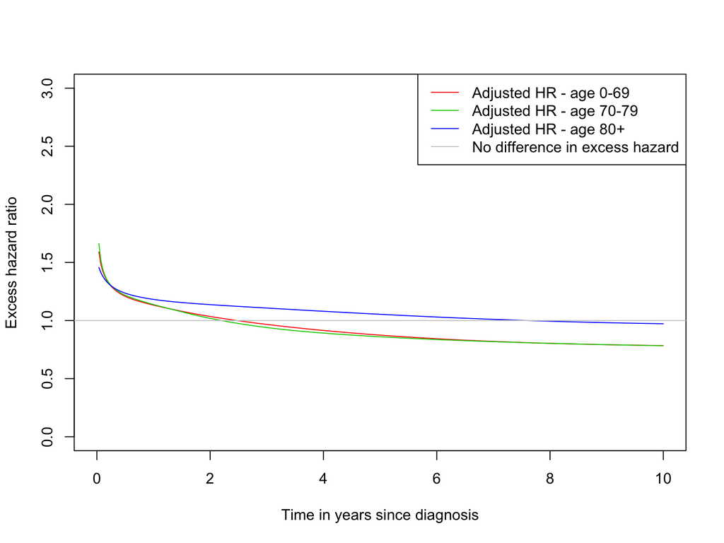

```r
# Age subgroups
age1 <- subset(dataset, age<70)
age2 <- subset(dataset, age>69 & age<80)
age3 <- subset(dataset, age>79)


fulla1<- stpm2(Surv(fupyrs, vitstat)~sex+nsx(age, df=3, centre=72)+tstage+nstage+mstage+morf+
                 sex:nsx(age, df=3, centre=72)+sex:tstage+sex:nstage+sex:mstage+sex:morf, df=4,
               tvc=list(sex=1, age=4, tstage=2),
               data=age1, bhazard=age1$rate, link.type="PH")
fulla2<- stpm2(Surv(fupyrs, vitstat)~sex+nsx(age, df=3, centre=72)+tstage+nstage+mstage+morf+
                 sex:nsx(age, df=3, centre=72)+sex:tstage+sex:nstage+sex:mstage+sex:morf, df=4,
               tvc=list(sex=1, age=4, tstage=2),
               data=age2, bhazard=age2$rate, link.type="PH")
fulla3<- stpm2(Surv(fupyrs, vitstat)~sex+nsx(age, df=3, centre=72)+tstage+nstage+mstage+morf+
                 sex:nsx(age, df=3, centre=72)+sex:tstage+sex:nstage+sex:mstage+sex:morf, df=4,
               tvc=list(sex=1, age=4, tstage=2),
               data=age3, bhazard=age3$rate, link.type="PH")

#Plot standardized hazard ratio curve in normal line
plot(fulla1,newdata=transform(age1, sex=0), type="meanhr", var="sex", add=F, line.col=2, lty=1,
           ylim=c(0,3), xlim=c(0,10), xlab="Time in years since diagnosis", ylab="Excess hazard ratio",rug=FALSE)
plot(fulla2,newdata=transform(age2, sex=0), type="meanhr", var="sex", add=T, line.col=3, lty=1,rug=FALSE)
plot(fulla3,newdata=transform(age3, sex=0), type="meanhr", var="sex", add=T, line.col=4, lty=1,rug=FALSE)
legend("topright",c("Adjusted HR - age 0-69","Adjusted HR - age 70-79", "Adjusted HR - age 80+","No difference in excess hazard"),
       col=c(2,3,4,"grey80"), lty=c(1,1,1,1))
abline(h=1, col="grey80",lty=1)
```

## APPENDIX 1

**Sensitivity analysis**

*Analysis of scenarios about smoking prevalence in bladder cancer patients and gen.pop.*

### Table A1

**Scenarios regarding smoking in male and female general population and bladder cancer patients**

Scenarios for sensitivity analysis

| Parameter | Scenario 1 | Scenario 2 |
| --- | --- | --- |
| % Smokers among male pts | 86 | 92 |
| % Smokers among female pts | 67 | 75 |
| % Smokers among male gen.pop. | 59 | 75 |
| % Smokers among female gen.pop. | 49 | 57 |
| Odds ratio of smoking for all-cause mortality | 2 | 2 |

Background hazard rates were adjusted according to these scenarios in SAS, code can be found here:  
(Note: here, sex is coded as 1=male 2=female)

```r
# data sens2;
# set sens;
#
# *SCENARIO 1;
# if sex=1 then do;
#       %let alpha=0.59;        * Proportion of smokers among general population of this gender;
#       %let or=2;              * Odds ratio of smoking for all cause-mortality ;
#       %let props=0.86;        * Proportion of smokers among bladder cancer patients of this gender;
#       %let propns=0.14;       * Proportion of non-smokers among bladder cancer patients of this gender;
#       prob_nonsmoking_s1=(((1+((prob-&alpha)*(1-&or)))*-1)+SQRT((( 1+((prob-&alpha)*(1-&or)))**2)+((4*prob)*((1-&or)*(&alpha-1)))))/(2*((1-&or)*(&alpha-1)));
#       prob_smoking_s1=(((prob_nonsmoking_s1/(1-prob_nonsmoking_s1))*&or)/(((prob_nonsmoking_s1/(1-prob_nonsmoking_s1))*&or)+1));
#             prob_1=((&props*prob_smoking_s1)+(&propns*prob_nonsmoking_s1));
# end;
# if sex=2 then do;
#       %let alpha=0.49;        * Proportion of smokers among general population of this gender;
#       %let or=2;              * Odds ratio of smoking for all cause-mortality ;
#       %let props=0.67;        * Proportion of smokers among bladder cancer patients of this gender;
#       %let propns=0.33;       * Proportion of non-smokers among bladder cancer patients of this gender;
#       prob_nonsmoking_s1=(((1+((prob-&alpha)*(1-&or)))*-1)+SQRT((( 1+((prob-&alpha)*(1-&or)))**2)+((4*prob)*((1-&or)*(&alpha-1)))))/(2*((1-&or)*(&alpha-1)));
#       prob_smoking_s1=(((prob_nonsmoking_s1/(1-prob_nonsmoking_s1))*&or)/(((prob_nonsmoking_s1/(1-prob_nonsmoking_s1))*&or)+1));
#             prob_1=((&props*prob_smoking_s1)+(&propns*prob_nonsmoking_s1));
# end;
# drop prob_nonsmoking_s1 prob_smoking_s1;
#
# *SCENARIO 2;
# if sex=1 then do;
#       %let alpha=0.75;              * Proportion of smokers among general population of this gender;
#       %let or=2;                  * Odds ratio of smoking for all cause-mortality ;
#       %let props=0.92;        * Proportion of smokers among bladder cancer patients of this gender;
#       %let propns=0.08;       * Proportion of non-smokers among bladder cancer patients of this gender;
#       prob_nonsmoking_s1=(((1+((prob-&alpha)*(1-&or)))*-1)+SQRT((( 1+((prob-&alpha)*(1-&or)))**2)+((4*prob)*((1-&or)*(&alpha-1)))))/(2*((1-&or)*(&alpha-1)));
#       prob_smoking_s1=(((prob_nonsmoking_s1/(1-prob_nonsmoking_s1))*&or)/(((prob_nonsmoking_s1/(1-prob_nonsmoking_s1))*&or)+1));
#             prob_2=((&props*prob_smoking_s1)+(&propns*prob_nonsmoking_s1));
# end;
# if sex=2 then do;
#       %let alpha=0.57;        * Proportion of smokers among general population of this gender;
#       %let or=2;                  * Odds ratio of smoking for all cause-mortality ;
#       %let props=0.75;        * Proportion of smokers among bladder cancer patients of this gender;
#       %let propns=0.25;       * Proportion of non-smokers among bladder cancer patients of this gender;
#       prob_nonsmoking_s1=(((1+((prob-&alpha)*(1-&or)))*-1)+SQRT((( 1+((prob-&alpha)*(1-&or)))**2)+((4*prob)*((1-&or)*(&alpha-1)))))/(2*((1-&or)*(&alpha-1)));
#       prob_smoking_s1=(((prob_nonsmoking_s1/(1-prob_nonsmoking_s1))*&or)/(((prob_nonsmoking_s1/(1-prob_nonsmoking_s1))*&or)+1));
#             prob_2=((&props*prob_smoking_s1)+(&propns*prob_nonsmoking_s1));
# end;
# drop prob_nonsmoking_s1 prob_smoking_s1;
#
# X_age=_age;
# X_period=_period;
# drop _age _period;
# run;
```

### Figure A1

**Excess hazard ratio for sex in bladder cancer patients adjusted for age, T-stage, N-stage, M-stage and histology based on different scenarios regarding smoking prevalence**

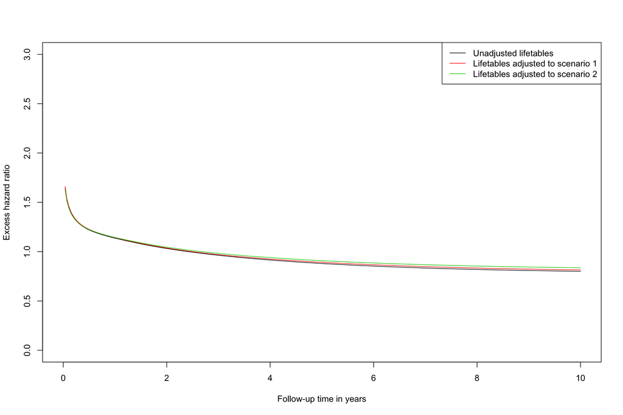

## ADDITIONAL RESULTS

*Not displayed in paper*

### Illustration of the proportional hazards assumption

**Hazard function for sex without and with TVC (i.e. proportional and non-proportional hazards assumed), unadjusted.**

Model **with** proportional hazards assumption:

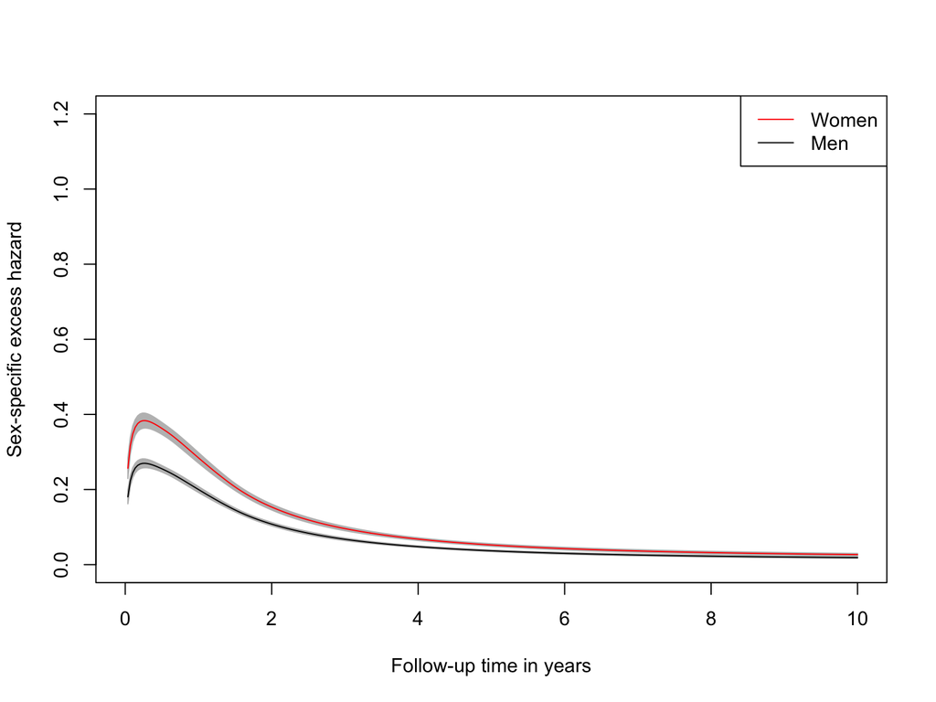

Model **without** proportional hazards assumption:

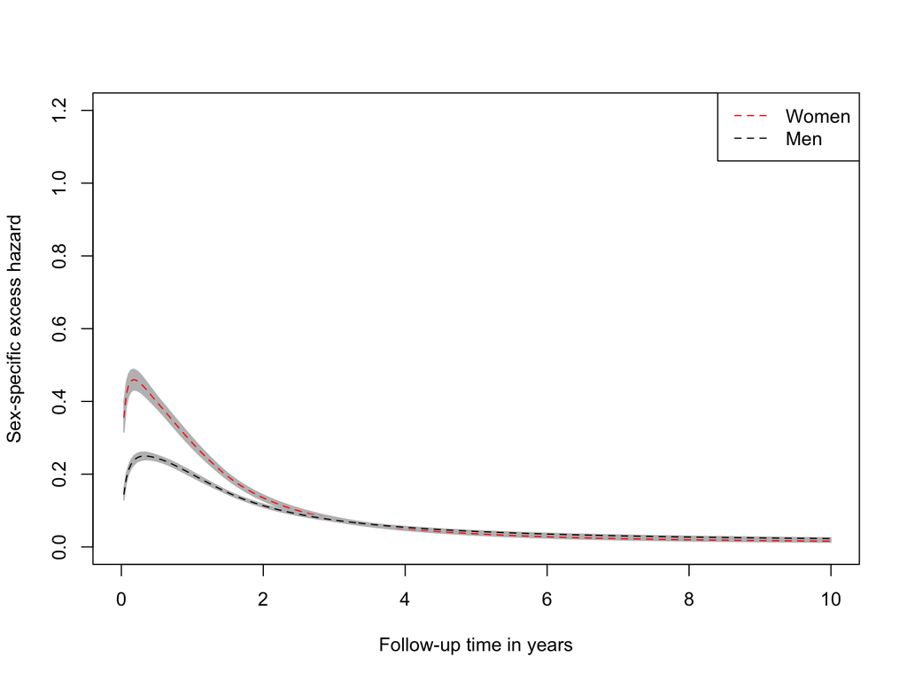

Comparing hazard ratio curves when assuming vs. not assuming proportional hazards:

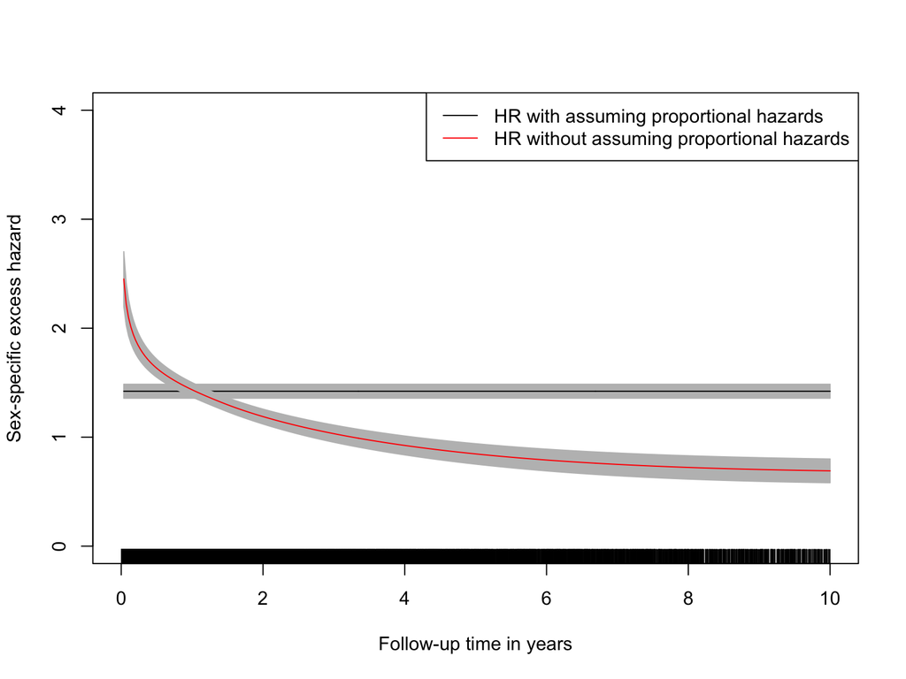

AIC for model **with** propotional hazards:

```
## [1] 75829.33
```

AIC for model **without** propotional hazards:

```
## [1] 75703.74
```